# Intergenerational mobility of career path

Wenzhi Du

2019/12/20

## Overview – does leaving family early increase independency of choosing careers?

Family bond builds up heritages, and in the meantime, it creates friction for social changes. The intergenerational mobility has been understood to play a central role in social fluidity. Consider the racial equality at workspace for example. Even if equal opportunity employers enforce racial-blind hiring process, equality remains hard to reach a satisfiable level. Among the many complicated social factors contribute to the difficulty of realizing truly equal opportunity, I would like to study the effect of family influence.

In the past, lots of family lineage are bounded with specific jobs, making a strong force against social fluidity. As a contrast, modern education encourages and facilitates young people to pursue their own interest that may or may not be the same as their parents. Nevertheless, the family influence is still a considerable factor for people’s career choice. In this study I will try to quantify the correlation between children and parents’ industry sector, and explore if leaving home early can enhance the independency of the child to choose their own career. We also want to see if this correlation between parent and children is becoming stronger or weaker over the years. The answer to this project may help people finding ways to a more equal world.

## Data

The data I use is extracted from GSS. We use following data: Variables:

| YEAR | Gss year for this respondent |
| --- | --- |
| ID | Respondent id number |
| INDUS10 | Respondent industry code (naics 2007) |
| PAIND10 | Fathers industry code (naics 2007) |
| MAIND10 | Mothers industry code (naics 2007) |
| FAMILY16 | Living with parents when 16 yrs old |
| BALLOT | Ballot used for interview |

Now we look at the variables. Firstly, notice that the number of observations in each year is different.

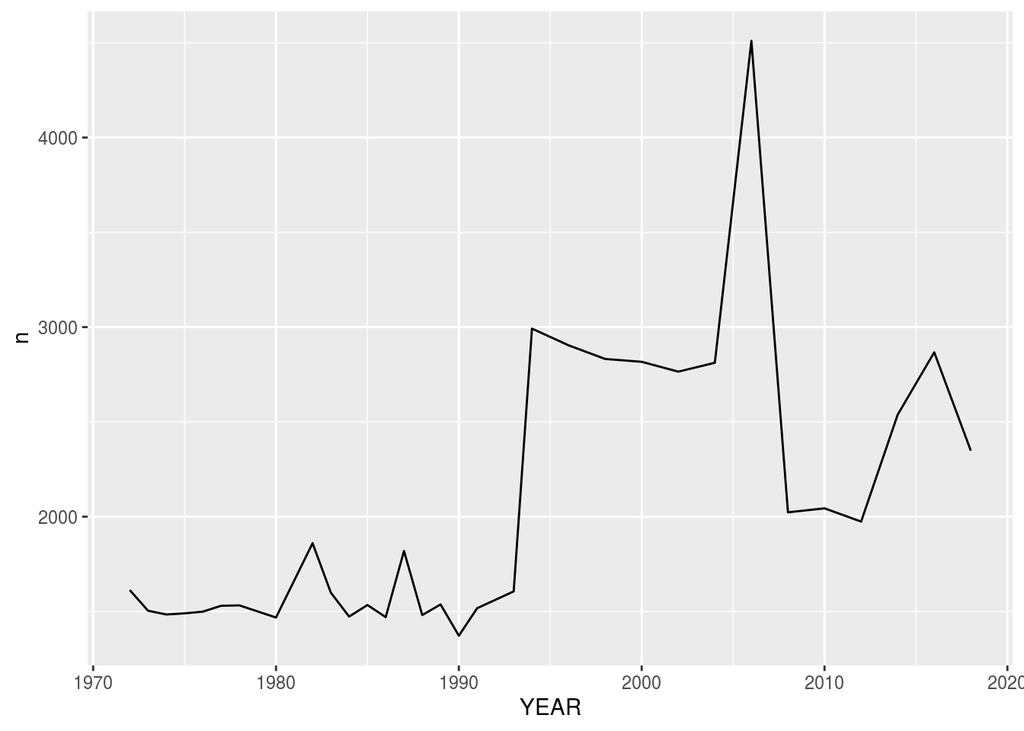

We will want to look at whether the respondents work in the same industry as their parents. The industry sector are coded with numbers. For the 64814 observations in total, about 300 different industry codes are included. The most common industry codes and frequency for the respondent, father and mother are respectively

```r
(GSS$INDUS10 %>% as.factor %>% summary)[1:10]
```

```
## 7860  770    0 8190 8680 7870 6990 5380 4970 9470
## 4014 3617 3455 2815 2597 1377 1106 1070 1030 1016
```

```r
(GSS$PAIND10 %>% as.factor %>% summary)[1:10]
```

```
##     0   770   170   180  9999  6080  3570  9997  2670  6170
## 11617  5673  3962  3288  1335  1305  1198  1126  1077  1033
```

```r
(GSS$MAIND10 %>% as.factor %>% summary)[1:10]
```

```
##     0  7860  8190  8680  9290  8270  1680  9999  5380  4970
## 43218  2464  1698  1265   915   628   606   595   559   476
```

Notice that industry sector code 0 means not in any industry. A huge fraction of parents, especially mothers, are in this category. For our purpose we want to know if the children has the same industry as at least one of father and mother. So we construct a new field SAME_IND

```r
GSS$SAME_IND <- (GSS$INDUS10 == GSS$PAIND10) | (GSS$INDUS10 == GSS$MAIND10)
```

The histogram of this variable is

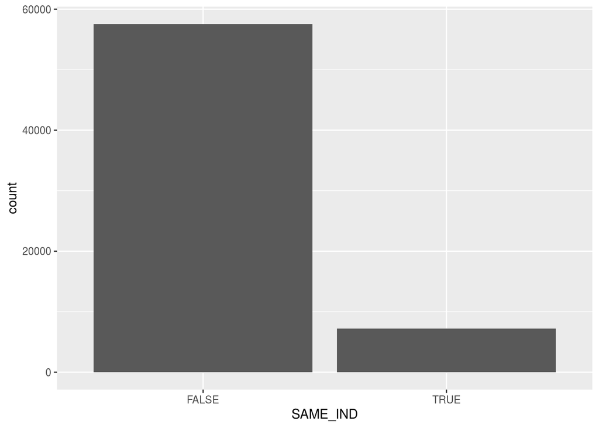

```r
GSS %>% select(SAME_IND) %>% ggplot(aes(x=SAME_IND)) + geom_histogram(stat = "count")
```

The data I want to use to predictors is whether the kid stay with family at the age of 16. The data have 10 levels of various combination. For simplicity we only consider the case of whether they are with at least one of direct parent. Hence we define

```r
GSS$WITH_PARENT = (GSS$FAMILY16 > 0) & (GSS$FAMILY16 <=5)
```

The histogram is

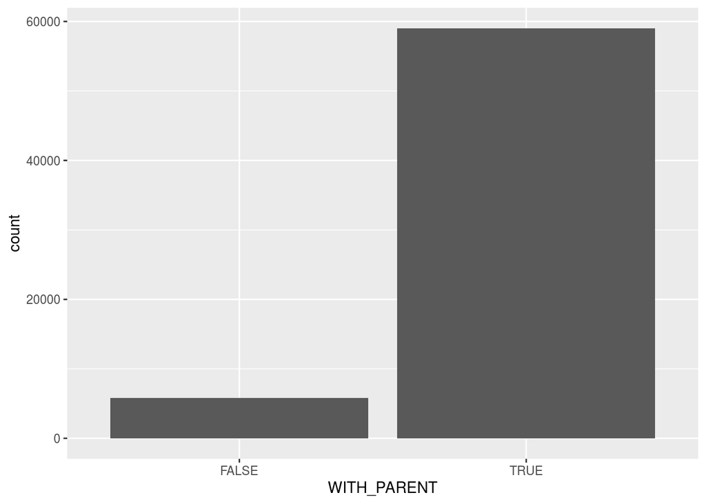

```r
GSS %>% select(WITH_PARENT) %>% ggplot(aes(x=WITH_PARENT)) + geom_histogram(stat = "count")
```

## Analysis

### Model: logistic regress

where $p$ is the probability the child has the same industry sector as parent (SAME_IND is TRUE), $x_1$ is years, and $x_2$ is whether the child is with parent at 16 (WITH_PARENT is TRUE).

Null hypothesis $H_0: \beta_1 =\beta_2 = 0$ and alternative hypothesis is one of them is none zero.

## Result

We do the logistic regression using glm in r:

```r
my.model <- glm(SAME_IND ~ WITH_PARENT + YEAR, family="binomial", data=GSS)
summary(my.model)
```

```
##
## Call:
## glm(formula = SAME_IND ~ WITH_PARENT + YEAR, family = "binomial",
##     data = GSS)
##
## Deviance Residuals:
##     Min       1Q   Median       3Q      Max
## -0.5751  -0.5172  -0.4712  -0.4258   2.3629
##
## Coefficients:
##                   Estimate Std. Error z value Pr(>|z|)
## (Intercept)     27.9847926  1.8741664  14.932  < 2e-16 ***
## WITH_PARENTTRUE  0.3125664  0.0498591   6.269 3.63e-10 ***
## YEAR            -0.0152196  0.0009385 -16.217  < 2e-16 ***
## ---
## Signif. codes:  0 '***' 0.001 '**' 0.01 '*' 0.05 '.' 0.1 ' ' 1
##
## (Dispersion parameter for binomial family taken to be 1)
##
##     Null deviance: 45403  on 64813  degrees of freedom
## Residual deviance: 45076  on 64811  degrees of freedom
## AIC: 45082
##
## Number of Fisher Scoring iterations: 5
```

```r
exp(coef(my.model))
```

```
##     (Intercept) WITH_PARENTTRUE            YEAR
##    1.424430e+12    1.366929e+00    9.848956e-01
```

We can see that the null hypothesis can be rejected at the level of $\alpha=0.001$, and in fact the effect is very significant. The odd ratio for those with parent over not with parent is 1.37 to have the same career as their parents. That means staying with parent at 16 makes a children more likely to inherit at least one of his/her parents industry sector choice.